# Homework 10

Solutions for Questions 1 and 2 will be available after Monday, November 2, 2026. No solution will be provided for Question 3.

Use the RLT package for Questions 1 and 2: `RLT` in R or `rlt` in Python. The node-size parameter is `nmin` in R and `min_samples_leaf` in Python; both stop splitting a node when it contains at most that many observations. The candidate-predictor parameter is `mtry` in both languages. Use ordinary random forests, with reinforcement turned off.

## Question 1: Bias-variance trade-off simulation

Two important tuning parameters of random forests are node size and `mtry`. We have performed some preliminary analysis in class. The goal of this question is to perform a larger simulation study for these two tuning parameters.

Consider a regression model with five jointly normally distributed predictors. Each predictor has mean 0 and variance 1, and the correlation between any two different predictors is 0.3. The response is

$$Y=X_1+X_3+X_5+\varepsilon,
\qquad \varepsilon\sim N(0,1),$$

where the noise is independent of the predictors. Thus the true regression function is $f(\mathbf{x})=x_1+x_3+x_5$.

1. Set up a simulation study with 100 repetitions. Generate 200 test predictor vectors once and keep them fixed. In each repetition, generate 200 new training observations and use the same training data for all tuning settings. Fit 500-tree forests, drawing 200 observations with replacement for each tree. Make the following two comparisons:
   - Fix `mtry` at 3 and vary node size over $1,5,10,20,30$.
   - Fix node size at 10 and vary `mtry` over $1,2,3,4,5$.

   Leave all other fitting parameters at their defaults. Record the predictions at each test point across repetitions. For each setting, estimate the squared bias and variance at each test point, then average them over the 200 test points. Compare predictions with $f(\mathbf{x})$ when estimating bias. Produce two figures, one for each tuning parameter, showing the averaged squared bias and variance. Set a random seed and report it.

```r
library(RLT)
library(MASS)
library(ggplot2)

set.seed(12142)

n_train <- 200
n_test <- 200
n_reps <- 100
n_trees <- 500
p <- 5

Sigma <- matrix(0.3, p, p)
diag(Sigma) <- 1

X_test <- mvrnorm(n_test, rep(0, p), Sigma)

f_test <- X_test[,1] + X_test[,3] + X_test[,5]

node_sizes <- c(1, 5, 10, 20, 30)
mtry_values <- c(1, 2, 3, 4, 5)

pred_node <- array(
  NA, dim = c(n_test, n_reps, length(node_sizes))
)

pred_mtry <- array(
  NA, dim = c(n_test, n_reps, length(mtry_values))
)


for (r in 1:n_reps) {

  X_train <- mvrnorm(n_train, rep(0, p), Sigma)

  Y_train <- X_train[,1] +
             X_train[,3] +
             X_train[,5] +
             rnorm(n_train)

  for (j in seq_along(node_sizes)) {

    fit <- RLT(
      x = X_train,
      y = Y_train,
      model = "regression",
      ntrees = n_trees,
      nmin = node_sizes[j],
      mtry = 3,
      replacement = TRUE,
      resample.prob = 1,
      reinforcement = FALSE,
      importance = FALSE
    )

    pred <- predict(fit, X_test)

    pred_node[, r, j] <- as.numeric(pred$Prediction)
  }

  for (j in seq_along(mtry_values)) {

    fit <- RLT(
      x = X_train,
      y = Y_train,
      model = "regression",
      ntrees = n_trees,
      nmin = 10,
      mtry = mtry_values[j],
      replacement = TRUE,
      resample.prob = 1,
      reinforcement = FALSE,
      importance = FALSE
    )

    pred <- predict(fit, X_test)

    pred_mtry[, r, j] <- as.numeric(pred$Prediction)
  }

  cat("Completed repetition:", r, "\n")
}
```

[output not shown]

[output cut: 45 more lines]

[output not shown]

```r
calculate_bias_variance <- function(predictions, f_test) {

  mean_pred <- apply(predictions, c(1, 3), mean)

  squared_bias <- (
    mean_pred -
    matrix(f_test, nrow = length(f_test),
           ncol = ncol(mean_pred))
  )^2

  variance <- apply(predictions, c(1, 3), var)

  data.frame(
    Squared_Bias = colMeans(squared_bias),
    Variance = colMeans(variance)
  )
}

# Calculate results
results_node <- calculate_bias_variance(
  pred_node, f_test
)

results_mtry <- calculate_bias_variance(
  pred_mtry, f_test
)

results_node$NodeSize <- node_sizes
results_mtry$mtry <- mtry_values

cat("\nResults for node size:\n")
```

```
Results for node size:
```

```r
print(results_node)
```

```
  Squared_Bias   Variance NodeSize
1    0.3203693 0.11222576        1
2    0.3221089 0.10157436        5
3    0.3506206 0.08293437       10
4    0.4467372 0.06490897       20
5    0.5544709 0.05704066       30
```

```r
cat("\nResults for mtry:\n")
```

```
Results for mtry:
```

```r
print(results_mtry)
```

```
  Squared_Bias   Variance mtry
1    0.9247389 0.04251473    1
2    0.4677719 0.06366935    2
3    0.3519678 0.08207438    3
4    0.3051763 0.10028671    4
5    0.2811819 0.11463070    5
```

```r
cat("\nMissing node predictions:",
    sum(is.na(pred_node)), "\n")
```

```
Missing node predictions: 0
```

```r
cat("Missing mtry predictions:",
    sum(is.na(pred_mtry)), "\n")
```

```
Missing mtry predictions: 0
```

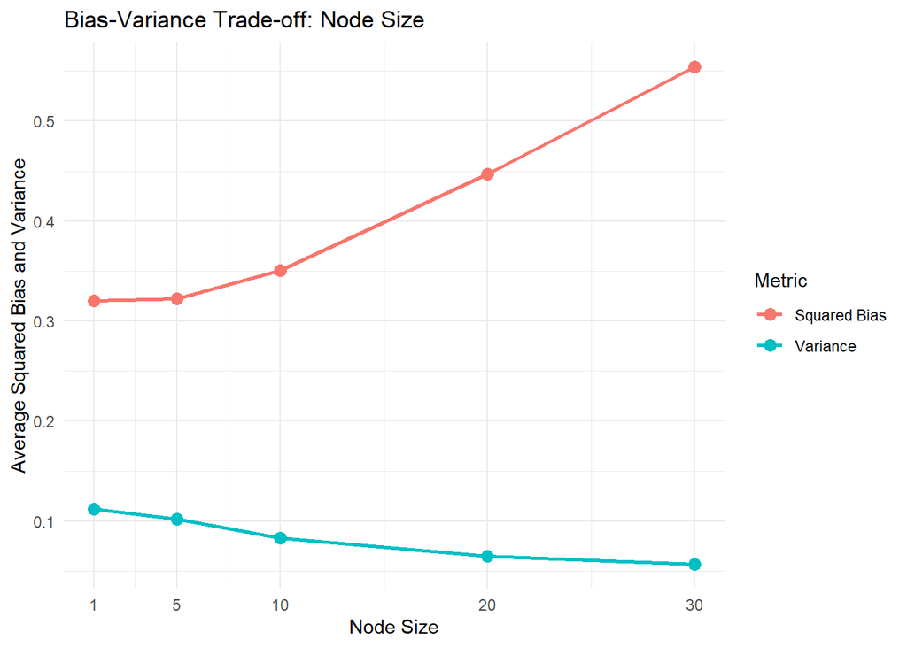

```r
node_plot <- rbind(
  data.frame(
    Value = node_sizes,
    Metric = "Squared Bias",
    Result = results_node$Squared_Bias
  ),
  data.frame(
    Value = node_sizes,
    Metric = "Variance",
    Result = results_node$Variance
  )
)

ggplot(node_plot,
       aes(x = Value, y = Result,
           color = Metric, group = Metric)) +
  geom_line(linewidth = 1) +
  geom_point(size = 3) +
  scale_x_continuous(breaks = node_sizes) +
  labs(
    title = "Bias-Variance Trade-off: Node Size",
    x = "Node Size",
    y = "Average Squared Bias and Variance",
    color = "Metric"
  ) +
  theme_minimal()
```

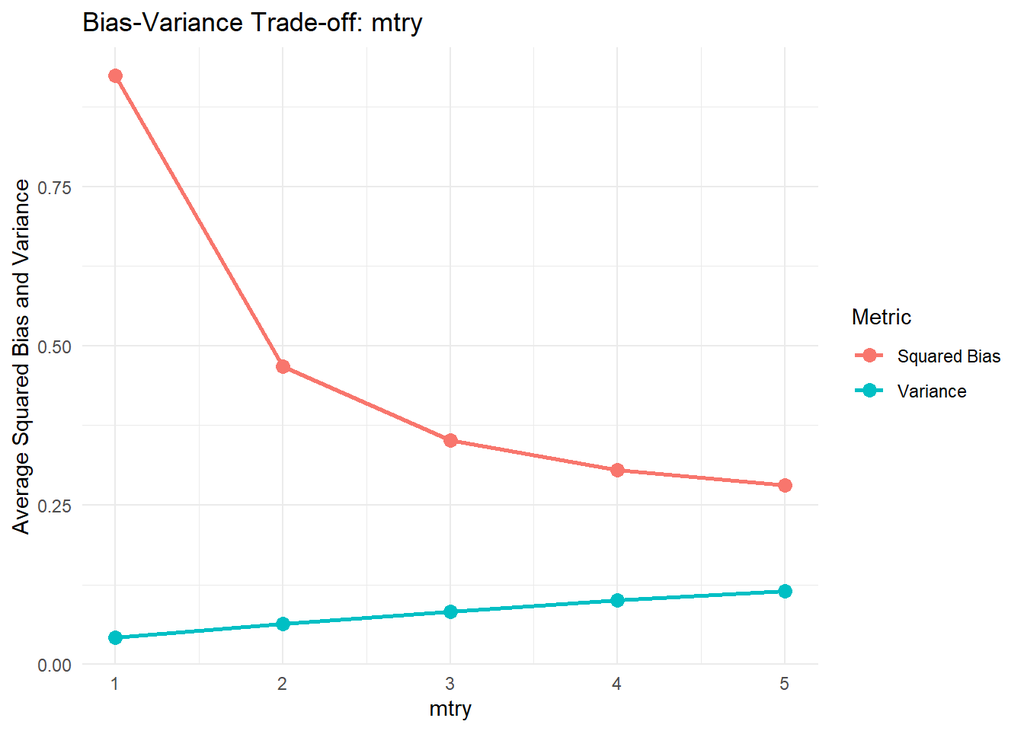

```r
mtry_plot <- rbind(
  data.frame(
    Value = mtry_values,
    Metric = "Squared Bias",
    Result = results_mtry$Squared_Bias
  ),
  data.frame(
    Value = mtry_values,
    Metric = "Variance",
    Result = results_mtry$Variance
  )
)

ggplot(mtry_plot,
       aes(x = Value, y = Result,
           color = Metric, group = Metric)) +
  geom_line(linewidth = 1) +
  geom_point(size = 3) +
  scale_x_continuous(breaks = mtry_values) +
  labs(
    title = "Bias-Variance Trade-off: mtry",
    x = "mtry",
    y = "Average Squared Bias and Variance",
    color = "Metric"
  ) +
  theme_minimal()
```

2. Discuss your results in terms of the bias-variance trade-off:
   - How does a large node size, such as 30, affect the fit in this example?
   - What are the benefits and drawbacks of using a large `mtry` value?
   - If each tree instead sampled 100 observations with replacement, would you expect the preferred node size to shift toward smaller or larger values? Explain your reasoning. You may use an additional simulation to help, but a particular pattern is not guaranteed.

```r
#Increasing the node size resulted in an increased square bias but a decreased variance, while increasing mtry decreases squared bias but increases variance. If each tree sampled 100 observations the node size would shift to larger values because that tree would have less training data. Smaller samples give less information so the trees with small terminal nodes can have high variance in the training data.
```

## Question 2: Tuning random forests for MNIST

Use `mnist-first2000.csv.gz` from the combined ZIP. It contains 2,000 MNIST observations, with the digit label `Digit` and 784 pixel values.

- From the first 1,000 observations, keep digits 1, 6, and 7 as the training data. From the remaining 1,000 observations, keep the same digits as the test data.
- Fit PCA to the training pixels, centering but not scaling them. Use the first 20 principal components as predictors, and project the test observations using the same training means and loadings.

Complete the following tasks using RLT classification forests with 1,000 trees. For each tree, draw a bootstrap sample of the same size as the training set.

1. Fit a random forest with the default `mtry` and node-size settings. Report the out-of-bag (OOB) misclassification rate.

```r
library(RLT)

mnist <- read.csv("C:/Users/ryans/OneDrive/Desktop/stat/stat423/stat432-fall2026/homework/week-10/data/mnist-first2000.csv")

train_all <- mnist[1:1000, ]
test_all  <- mnist[1001:2000, ]

digits <- c(1, 6, 7)

train <- train_all[train_all$Digit %in% digits, ]
test  <- test_all[test_all$Digit %in% digits, ]

y_train <- factor(train$Digit, levels = digits)
y_test  <- factor(test$Digit, levels = digits)

x_train <- as.matrix(train[, -1])
x_test  <- as.matrix(test[, -1])

pca <- prcomp(x_train, center = TRUE, scale. = FALSE)

pc_train <- pca$x[, 1:20]

pc_test <- scale(
  x_test,
  center = pca$center,
  scale = FALSE
) %*% pca$rotation[, 1:20]

set.seed(123)

fit <- RLT(
  x = pc_train,
  y = y_train,
  model = "classification",
  ntrees = 1000,
  resample.prob = 1,
  print.summary = 1
)
```

```
Reinforcement Learning Trees for classification model
RLT all tuning parameters detail: ---------------------------------------
Use CPU cores:                                          useCores = 1
Data number of observations:                                   n = 327
Data number of features:                                       p = 20
Number of trees:                                          ntrees = 1000
Number of variables try at each split:                      mtry = 6
Minimum terminal node size:                                 nmin = 5
Minimum proportion of sample size for child node:          alpha = 0.40
Splitting point generating method:                     split_gen = Random
Number of random splits:                              nspliteach = 1
Sample with replacement:                             replacement = Yes
Re-sampling proportion:                            resample_prob = 100.0%
Number of OOB data impute:                              npermute = 1
Subject weights used:                             use_sub_weight = No
Variable weights used:                            use_sub_weight = No
Track each observations:                               track_obs = No
Use reinforcement learning:                        reinforcement = No
-------------------------------------------------------------------------
```

```r
summary(fit)
```

[output not shown]

```r
fit$AllError[1000, 21]
```

```
[1] 0.1465517
```

2. Construct a grid of `mtry` and node-size values to tune the model. Select the setting using OOB misclassification rate. Report the OOB error for each setting and the selected values. Calculate and present the selected forest’s OOB permutation variable importance for the 20 principal components. Comment on your results.

```r
library(RLT)

mtry_values <- c(2, 4, 6, 10, 15, 20)
nmin_values <- c(2, 5, 10, 20)

grid <- expand.grid(
  mtry = mtry_values,
  nmin = nmin_values
)

models <- vector("list", nrow(grid))
oob_errors <- numeric(nrow(grid))

for (i in seq_len(nrow(grid))) {

  set.seed(1000 + i)

  models[[i]] <- RLT(
    x = pc_train,
    y = y_train,
    model = "classification",
    ntrees = 1000,
    mtry = grid$mtry[i],
    nmin = grid$nmin[i],
    replacement = TRUE,
    resample.prob = 1,
    importance = TRUE,
    print.summary = 0
  )

  err <- models[[i]]$AllError

  oob_errors[i] <- mean(
    err[, "nonPermute"],
    na.rm = TRUE
  )
}

results <- data.frame(
  mtry = grid$mtry,
  nmin = grid$nmin,
  OOB_Error = oob_errors
)

results <- results[order(results$OOB_Error), ]

print(results, row.names = FALSE)
```

```
 mtry nmin OOB_Error
   20    2 0.1013462
   20    5 0.1017237
   20   10 0.1039938
   20   20 0.1072389
   15    2 0.1150541
   15    5 0.1156868
   15   10 0.1197659
   15   20 0.1217769
   10    2 0.1396463
   10    5 0.1449198
   10   10 0.1456219
   10   20 0.1597937
    6    2 0.1913916
    6    5 0.1949495
    6   10 0.2023138
    6   20 0.2146260
    4    2 0.2382838
    4    5 0.2428750
    4   10 0.2515682
    4   20 0.2714739
    2    2 0.3227968
    2    5 0.3291505
    2   10 0.3482487
    2   20 0.3626198
```

```r
best_row <- which.min(oob_errors)

best_mtry <- grid$mtry[best_row]
best_nmin <- grid$nmin[best_row]
best_fit <- models[[best_row]]

cat("Selected mtry:", best_mtry, "\n")
```

```
Selected mtry: 20
```

```r
cat("Selected nmin:", best_nmin, "\n")
```

```
Selected nmin: 2
```

```r
cat("Lowest mean per-tree OOB error:",
    round(oob_errors[best_row], 4), "\n")
```

```
Lowest mean per-tree OOB error: 0.1013
```

```r
importance <- data.frame(
  Principal_Component = paste0("PC", 1:20),
  Importance = as.numeric(best_fit$VarImp)
)

importance <- importance[
  order(importance$Importance, decreasing = TRUE),
]

print(importance, row.names = FALSE)
```

```
 Principal_Component Importance
                 PC2 4.54009370
                 PC1 2.19901250
                 PC3 0.25176183
                PC11 0.18280139
                 PC5 0.15085360
                 PC6 0.09890742
                PC18 0.07287272
                 PC4 0.06652237
                 PC7 0.05819956
                PC19 0.04210415
                PC16 0.04120418
                PC12 0.03685867
                PC10 0.03543299
                PC14 0.03399194
                PC17 0.02914683
                PC13 0.02273378
                 PC9 0.02165172
                 PC8 0.01974527
                PC15 0.01962072
                PC20 0.01926065
```

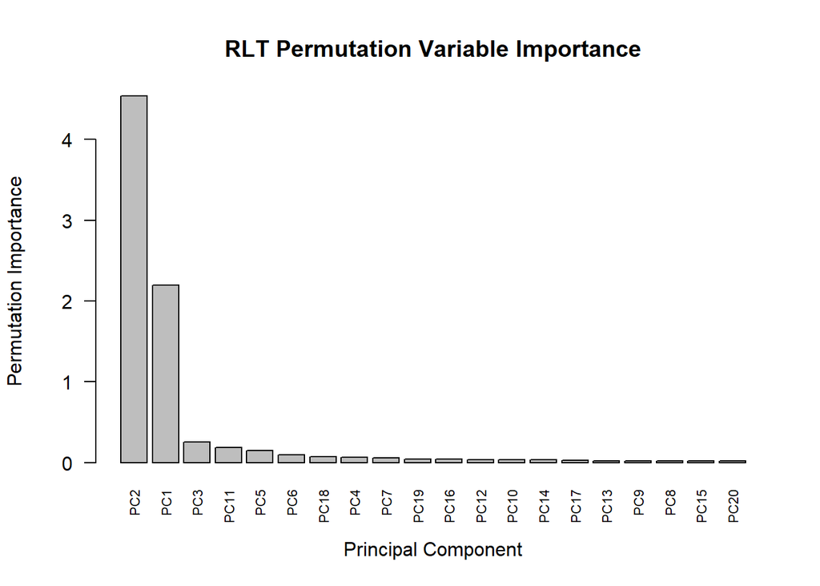

```r
barplot(
  importance$Importance,
  names.arg = importance$Principal_Component,
  las = 2,
  cex.names = 0.7,
  main = "RLT Permutation Variable Importance",
  xlab = "Principal Component",
  ylab = "Permutation Importance"
)
```

3. Apply the selected model to the test data and report the misclassification rate and confusion matrix. Use the test labels only for this final assessment.

```r
pred <- predict(best_fit, testx = pc_test)

pred_class <- factor(
  pred$Prediction,
  levels = c(0, 1, 2),
  labels = c("1", "6", "7")
)

conf_matrix <- table(
  Actual = y_test,
  Predicted = pred_class
)

print(conf_matrix)
```

```
      Predicted
Actual   1   6   7
     1 103   0   1
     6   3 103   0
     7   0   3 104
```

```r
test_error <- mean(pred_class != y_test)
cat("Test misclassification rate:", test_error, "\n")
```

```
Test misclassification rate: 0.02208202
```

## Question 3: Planning a random-forest analysis skill

In earlier homework, some students wrote long skill files with detailed instructions, while others wrote short skills emphasizing their specific requirements or references. These approaches may perform differently depending on the AI and the task. A capable AI may already know standard ways to perform an analysis, so some instructions may be redundant, add little value, or sometimes make the analysis worse. It may be more useful to specify your personal choices for the analysis. An AI with more limited knowledge may benefit from detailed instructions that remind it of the steps to perform.

1. Write one paragraph describing how you would write a skill that directs an AI to perform a random-forest analysis and produce a report for a future dataset. Discuss how you would balance standard analysis instructions with your personal preferences, considering the AI’s capabilities.

```r
# You need to specifically include every step of the process for random-forest analysis. Start with importing the data, understanding it, and formatting it for the analysis. Then build the model with the training data and tune the parameters accordingly. then evaluate the error and calculate the variable importance. You should include the requirements for the analysis but also personal preference for how that report should be output, either for yourself or for a client to read.
```

2. Provide **10 instructions** you would consider including in the skill, **ordered from the most basic instructions to the more personal preferences**. Your list may cover computation, tuning, tables, figures, interpretation, presentation, or other aspects of a random-forest report.

You only need to discuss how the skill should be written. You are not required to write a complete skill file or test it.

```r
# 1. Load and inspect the data: Import the dataset, identify the response and predictor variables, and check for missing values, duplicates, and incorrect data types.

#2. Prepare the data: Clean the dataset and make any necessary transformations or encoding changes before building the model.

#3. Split the data: Divide the observations into training and testing sets, using the training set to build the model and the testing set for final evaluation.

#4. Build the random forest: Train a random forest model using an appropriate method for the problem, whether classification or regression.

#5. Tune model parameters: Test different values for parameters such as the number of variables considered at each split (mtry), minimum node size, and number of trees to find a model with good performance.

#6. Evaluate OOB error: Calculate and report the out-of-bag error to estimate model performance during training and compare different parameter settings.

#7. Calculate variable importance: Identify and rank the most important predictor variables, explaining how they contribute to the model's predictions.

#8. Include tables and figures: Present important results using organized tables and clear graphs, including parameter comparisons, variable importance plots, and model performance summaries.

#9. Explain the results clearly: Interpret the findings in plain language, discuss which model performed best, identify important predictors, and mention any limitations.

#10. Follow my presentation preferences: Organize the report with clear headings, concise paragraphs, readable tables, and labeled figures. Include a brief summary of the main findings at the beginning and avoid unnecessary technical jargon.
```